# Geography 176A

##### Question 2:

###### In this question, we are going to look at the story of 4 states and the impact scale can have on data interprtation. The states include: New York, California, Louisiana, and Florida.

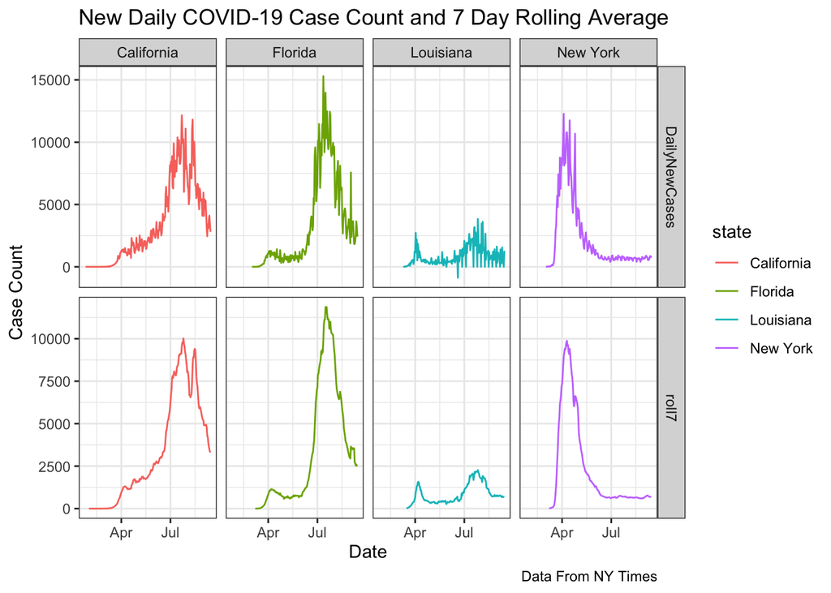

```r
#create state level daily new and rolling 7 day average
states.of.interest <-  c("New York", "California", "Louisiana", "Florida")
stateLvl<- covid %>%
 filter(state %in% states.of.interest) %>%
 group_by(state,date) %>%
  summarise(cases=sum(cases))  %>%
 mutate(DailyNewCases = c(NA, diff(cases)),
         roll7=rollmean(DailyNewCases,7,fill = NA, align = "right")) %>%
  pivot_longer(cols = c(DailyNewCases,roll7),names_to = "type",values_to="values")

#create ggplot of daily new cases and 7 day average
plot01Lab2<- ggplot(data = stateLvl, aes(x=date, y=values))+
  geom_line(aes(col = state))+
  labs(x="Date", y="Case Count",
       title= "New Daily COVID-19 Case Count and 7 Day Rolling Average",
       caption = "Data From NY Times")+
  facet_grid(type~state, scales = "free_y")+
  theme_bw()+
  ggsave(plot = last_plot(), file= "../img/COVIDPlot.png")
plot01Lab2
```

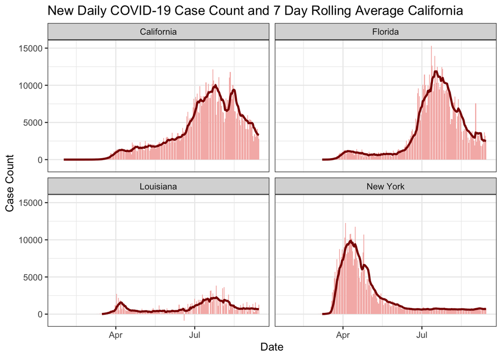

```r
#NY Times style
stateLvls<- covid %>%
 filter(state %in% states.of.interest) %>%
 group_by(state,date) %>%
  summarise(cases=sum(cases))  %>%
 mutate(DailyNewCases = c(NA, diff(cases)),
         roll7=rollmean(DailyNewCases,7,fill = NA, align = "right"))

#NY Times style ggplot of new daily cases
nyTimes01<-  ggplot(data=stateLvls, aes(x = date)) +
  geom_col(aes(y = DailyNewCases), col = NA, fill = "#F5B8B5") +
  geom_line(aes(y = roll7), col = "darkred", size = 1) +
  theme_bw()+
  labs(title = paste("New Daily COVID-19 Case Count and 7 Day Rolling Average", state.interest), x="Date", y= "Case Count") +
  facet_wrap(~state)+
  ggsave(plot = last_plot(), file= "../img/NYTIIMESCOVIDPlot.png")
nyTimes01
```

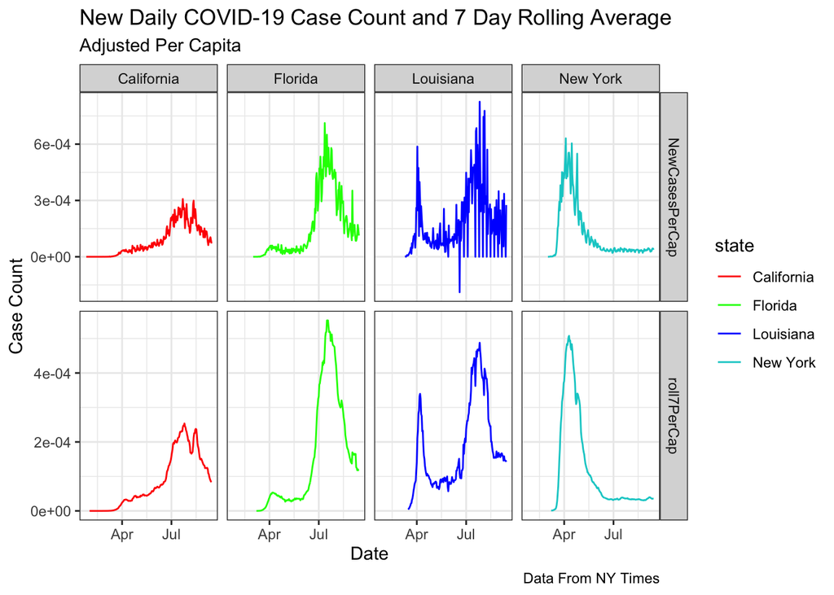

```r
#use region data to get common key
region<- data.frame(State = state.abb, state = state.name)

#statelvl1 has roll7, daily new cases, and total cases
stateLv1<-  covid %>%
 filter(state %in% states.of.interest) %>%
 group_by(state,date) %>%
  summarise(cases=sum(cases))  %>%
 mutate(DailyNewCases = c(NA, diff(cases)),
         roll7=rollmean(DailyNewCases,7,fill = NA, align = "right")) %>%
  ungroup()



#table join region(aka state abbr) to stateLvl1
stateLvl2<-left_join(stateLv1,region,by = "state")


#clean up population data to match at the stateLvl2, trick with divide by 2 to negate pop double counts
popEst1<- popEst %>%
  group_by(State) %>%
  summarise(totalPop<- sum(POP_ESTIMATE_2019)/2)


#table join the state_abb covid data to usda population data, now has correct state pop associated with covid cases
#table also has new cases/pop and rolling7 per capita
#recreating facet_grid to show total population
stateLvl3<-left_join(stateLvl2,popEst1,by = "State") %>%
  rename(state_pop = "totalPop <- sum(POP_ESTIMATE_2019)/2") %>%
  mutate(NewCasesPerCap= DailyNewCases/state_pop) %>%
  mutate(roll7PerCap=roll7/state_pop) %>%
  pivot_longer(cols = c(NewCasesPerCap,roll7PerCap),names_to ="type",values_to ="values")

#make adjusted for population plot
stateLvl3plot<- ggplot(data = stateLvl3, aes(x=date,y=values))+
  geom_line(aes(color=state))+
  scale_color_manual(values= c("California" = "red", "Florida" = "green",
      "Louisiana" = "blue", "New York"= "Cyan3")) +
  labs(x="Date", y="Case Count",
       title= "New Daily COVID-19 Case Count and 7 Day Rolling Average",subtitle = "Adjusted Per Capita",
       caption = "Data From NY Times")+
  facet_grid(type~state, scales = "free_y")+
  theme_bw()+
  ggsave(plot = last_plot(), file= "../img/COVIDPlotAdjust.png")

stateLvl3plot
```

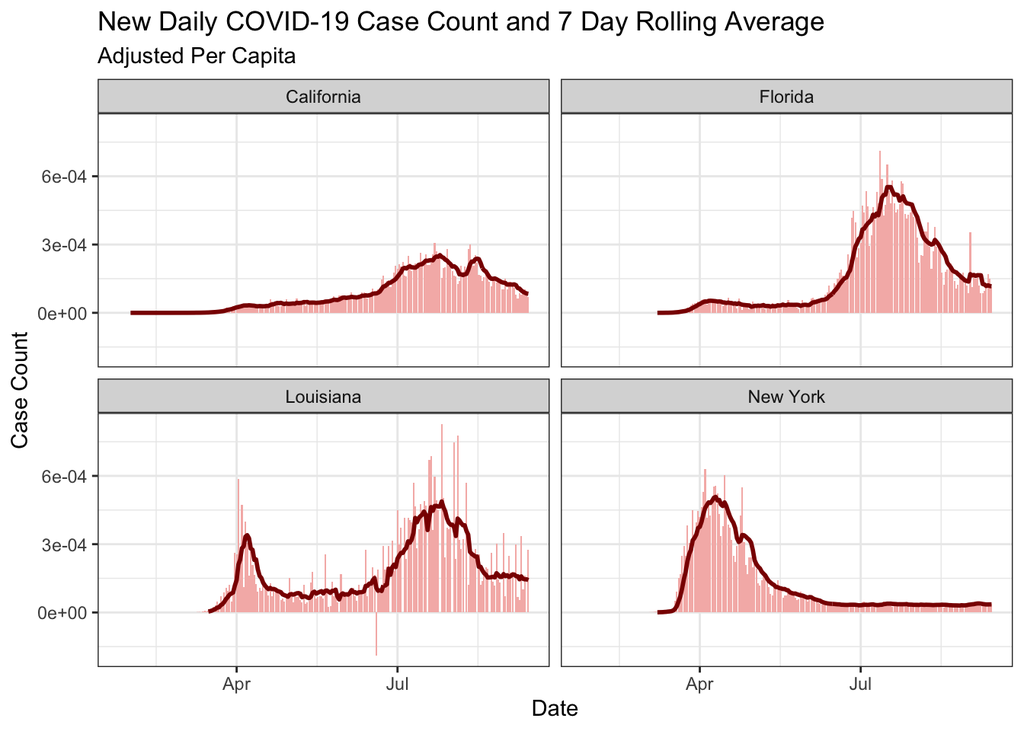

```r
#NY Times style
stateLvls3<-left_join(stateLvl2,popEst1,by = "State") %>%
  rename(state_pop = "totalPop <- sum(POP_ESTIMATE_2019)/2") %>%
  mutate(NewCasesPerCap= DailyNewCases/state_pop) %>%
  mutate(roll7PerCap=roll7/state_pop)

#NY Times style ggplot per capita
nyTimes02<-  ggplot(data=stateLvls3, aes(x = date)) +
  geom_col(aes(y = NewCasesPerCap), col = NA, fill = "#F5B8B5") +
  geom_line(aes(y = roll7PerCap), col = "darkred", size = 1) +
  theme_bw() +
  labs(title = paste("New Daily COVID-19 Case Count and 7 Day Rolling Average"),subtitle = "Adjusted Per Capita", x= "Date", y= "Case Count") +
  facet_wrap(~state)+
  ggsave(plot = last_plot(), file= "../img/NYTIMEScovidPerCap.png")
nyTimes02
```

##### Results: Scaling COVID-19 cases based on the respective state population makes the relative amount of cases appear to be less severe in some states and more severe in others. This occurs because we are comparing only raw case data values. California, a highly populated state is likely to have more cases than Lousiana, a less populated state. When state cases are adjusted for population, using cases per capita the relative proportion of people within each state contracting COVID-19 becomes more clear.

##### Question 3: Exploring spatial data

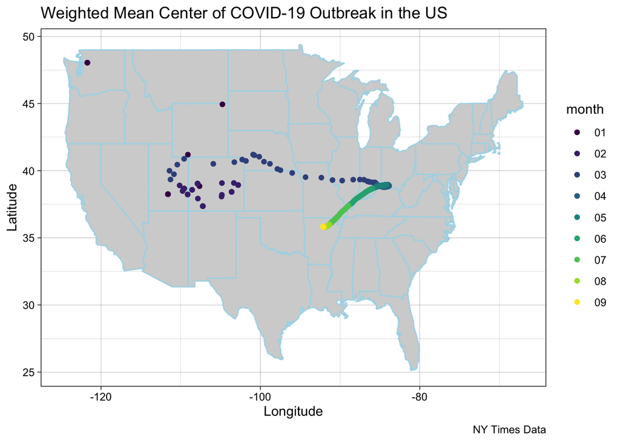

```r
#read in county spatial data
counties = read_csv("../data/county-centroids.csv")

#Join to COVID-19 Data
#get daily cumulative cases
#find weighted mean
covidSpatial<-inner_join(covid,counties,by = "fips") %>%
  group_by(date) %>%
  summarise(wmX= sum(LON*cases)/sum(cases),wmY= sum(LAT*cases)/sum(cases),cases=sum(cases)) %>%
  mutate(month=format(date,"%m"))


#Create weighted mean plot
weightedMeanPlot<- ggplot(data = covidSpatial)+
  borders("state",fill="light gray", colour = "light blue")+
  scale_color_viridis_d()+
  geom_point(aes(x=wmX, y=wmY, color= month))+
  theme_linedraw()+
  labs(color= "month",
       size = "Cases (1,000,000)",
       x="Longitude",
       y="Latitude",
       title = "Weighted Mean Center of COVID-19 Outbreak in the US",
       caption = "NY Times Data")+
      ggsave(plot = last_plot(), file= "../img/COVIDweightedMean.png")

weightedMeanPlot
```